# TV’s Golden Age

## Introduction

[GitHub Repository](https://github.com/rfordatascience/tidytuesday/tree/master/data/2019/2019-01-08)

### Load Data

```r
tv.data <- read.csv('https://raw.githubusercontent.com/rfordatascience/tidytuesday/master/data/2019/2019-01-08/IMDb_Economist_tv_ratings.csv')
```

## Initial Exploration

```r
kable(head(tv.data, 5))
```

| titleId | seasonNumber | title | date | av_rating | share | genres |
| --- | --- | --- | --- | --- | --- | --- |
| tt2879552 | 1 | 11.22.63 | 2016-03-10 | 8.4890 | 0.51 | Drama,Mystery,Sci-Fi |
| tt3148266 | 1 | 12 Monkeys | 2015-02-27 | 8.3407 | 0.46 | Adventure,Drama,Mystery |
| tt3148266 | 2 | 12 Monkeys | 2016-05-30 | 8.8196 | 0.25 | Adventure,Drama,Mystery |
| tt3148266 | 3 | 12 Monkeys | 2017-05-19 | 9.0369 | 0.19 | Adventure,Drama,Mystery |
| tt3148266 | 4 | 12 Monkeys | 2018-06-26 | 9.1363 | 0.38 | Adventure,Drama,Mystery |

```r
# Drop 'titleId' Column
tv.data <- tv.data %>% select(-titleId)

length(unique(tv.data$title))
```

```
## [1] 868
```

```r
kable(summary(tv.data))
```

|  | seasonNumber | title | date | av_rating | share | genres |
| --- | --- | --- | --- | --- | --- | --- |
|  | Min. : 1.000 | Length:2266 | Length:2266 | Min. :2.704 | Min. : 0.00 | Length:2266 |
|  | 1st Qu.: 1.000 | Class :character | Class :character | 1st Qu.:7.731 | 1st Qu.: 0.10 | Class :character |
|  | Median : 2.000 | Mode :character | Mode :character | Median :8.115 | Median : 0.32 | Mode :character |
|  | Mean : 3.264 | NA | NA | Mean :8.061 | Mean : 1.28 | NA |
|  | 3rd Qu.: 4.000 | NA | NA | 3rd Qu.:8.490 | 3rd Qu.: 1.09 | NA |
|  | Max. :44.000 | NA | NA | Max. :9.682 | Max. :55.65 | NA |

Initially I decided to drop the *titleId* column, as I didn’t see much use for it in the data exploration since we already have *title*. Of the 2266 observations within the data set, there are 868 unique shows. The number of seasons range from 1 to 44 (which we will need to explore this 44 season show to see if it is true). The average rating ranges from 2.704 to 9.682, as well as shares ranging from 0 to 55.65.

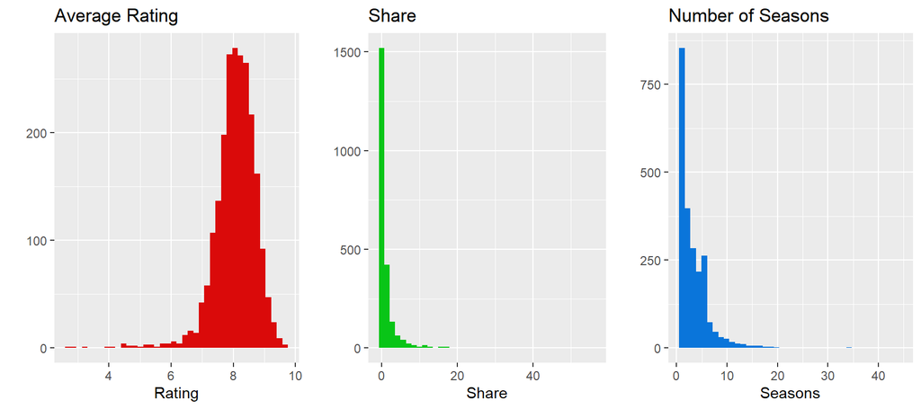

```r
av.plot <- ggplot(tv.data, aes(x=av_rating)) + geom_histogram(bins=40, fill="#DA0A0A") +
  xlab('Rating') + ylab('') + ggtitle('Average Rating')
share.plot <- ggplot(tv.data, aes(x=share)) + geom_histogram(bins=40, fill="#09C517") +
  xlab('Share') + ylab('') + ggtitle('Share')
season.plot <- ggplot(tv.data, aes(x=seasonNumber)) + geom_histogram(bins=40, fill="#0A75DA") +
  xlab('Seasons') + ylab('') + ggtitle('Number of Seasons')
grid.arrange(av.plot, share.plot, season.plot, ncol=3)
```

## Month, Day, & Year: Creation/Exploration

```r
tv.data <- tv.data %>% mutate(year = year(date),
                              month = month(date),
                              day = day(date))

tv.data <- tv.data[c(1,2,3,7,8,9,4,5,6)]
kable(t(tv.data[1,]), col='Observation #1')
```

|  | Observation #1 |
| --- | --- |
| seasonNumber | 1 |
| title | 11.22.63 |
| date | 2016-03-10 |
| year | 2016 |
| month | 3 |
| day | 10 |
| av_rating | 8.489 |
| share | 0.51 |
| genres | Drama,Mystery,Sci-Fi |

I decided to split the *date* feature into 3 subset features: *year*, *month*, and *day* using the [lubridate](https://lubridate.tidyverse.org/) package. I also reordered the columns to put these after the *date* feature instead of the end of the data frame cause my OCD didn’t like how it looked…

#### Year

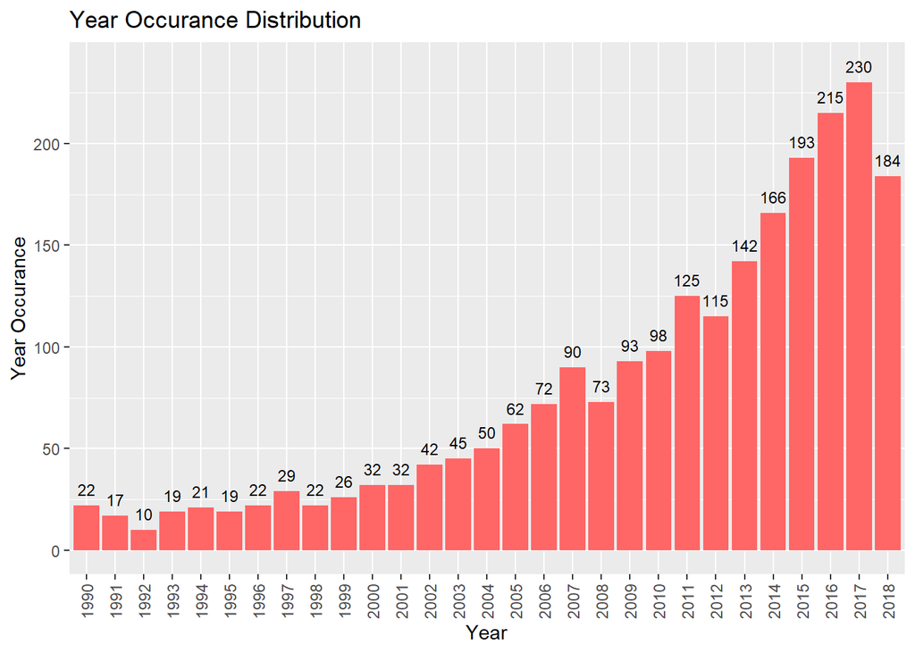

```r
ggplot(tv.data, aes(x=factor(year))) + geom_bar(fill= "#FF6666") + ylab('Year Occurance') +
  xlab('Year') + ggtitle('Year Occurance Distribution') +
  theme(axis.text.x = element_text(angle = 90, vjust = 0.5)) +
  geom_text(aes(y=..count.. + 8, label=..count..), stat='count', size = 3)
```

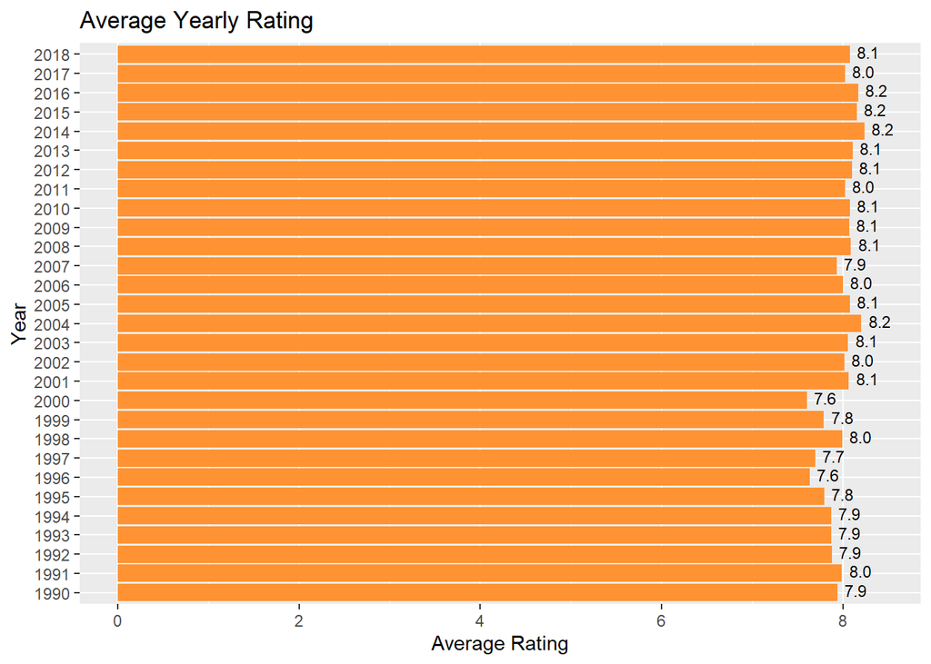

```r
tv.data %>% select(year, av_rating) %>% group_by(year) %>%
  summarize(average_rating = mean(av_rating)) %>%
  {ggplot(., aes(x=factor(year), y=average_rating)) + geom_col(fill= "#FF9333") +
      coord_flip() + xlab('Year') + ylab('Average Rating') +
      ggtitle('Average Yearly Rating') +
      geom_text(aes(label=sprintf("%.1f", average_rating),
                    y=average_rating + 0.2), size=3, vjust=0.3)}
```

#### Month

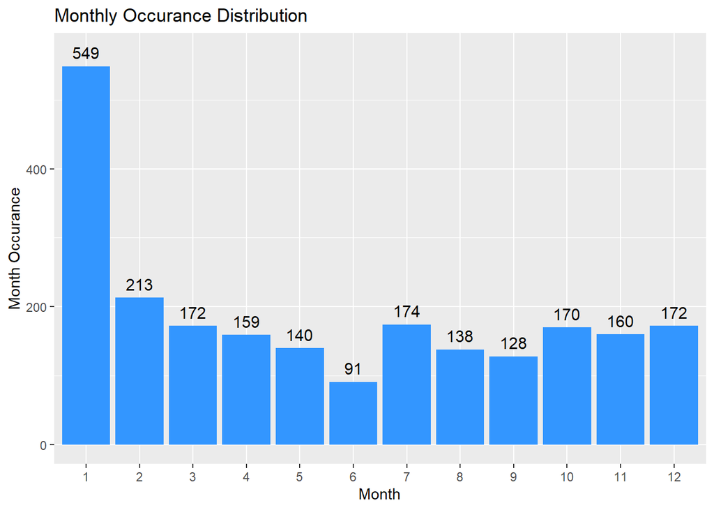

```r
ggplot(tv.data, aes(x=factor(month))) + geom_bar(fill= "#3396FF") + ylab('Month Occurance') +
  xlab('Month') + ggtitle('Monthly Occurance Distribution') +
  geom_text(aes(y=..count.. + 20, label=..count..), stat='count', size = 4)
```

## One Hot Encoding for Genres

```r
genres.types <- unique(unlist(strsplit(unlist(unique(tv.data$genres)), ',')))
tv.data[genres.types] <- rep(NA, nrow(tv.data))

for (idx in 1:nrow(tv.data)) {
  tv.data[idx, genres.types] <- as.numeric(genres.types %in% unlist(strsplit(tv.data$genres[idx], ',')))
}

kable(t(tv.data[1,]), col='Observation #1')
```

|  | Observation #1 |
| --- | --- |
| seasonNumber | 1 |
| title | 11.22.63 |
| date | 2016-03-10 |
| year | 2016 |
| month | 3 |
| day | 10 |
| av_rating | 8.489 |
| share | 0.51 |
| genres | Drama,Mystery,Sci-Fi |
| Drama | 1 |
| Mystery | 1 |
| Sci-Fi | 1 |
| Adventure | 0 |
| Action | 0 |
| Crime | 0 |
| Fantasy | 0 |
| Family | 0 |
| Romance | 0 |
| Comedy | 0 |
| Thriller | 0 |
| Biography | 0 |
| Horror | 0 |
| Music | 0 |
| Sport | 0 |
| History | 0 |
| Documentary | 0 |
| Animation | 0 |
| Western | 0 |
| War | 0 |
| Reality-TV | 0 |
| Musical | 0 |

The original *genres* feature was a single string that listed all genres only separated by a comma. There probably is a fast way out there (or a package that could handle this for me) but my method still only took a few seconds to run so I’m not too worried about optimizing it. I initially got all unique genres strings from the data frame, which I then split on the commas, and finally only kept the unique values from this split (which was 22 total genres). I then created empty columns, looped over all rows for the given columns, and one hot encoded the features to have a 1 is the *genre* feature contained any of the given genres and a 0 if it does not. I was having an issue of the values being filled column wise, so looping across rows allowed me to fill by rows rather than columns (again, may not be the best way to do it but it still executed quickly so I’ll go with it).

#### Most Common Genres

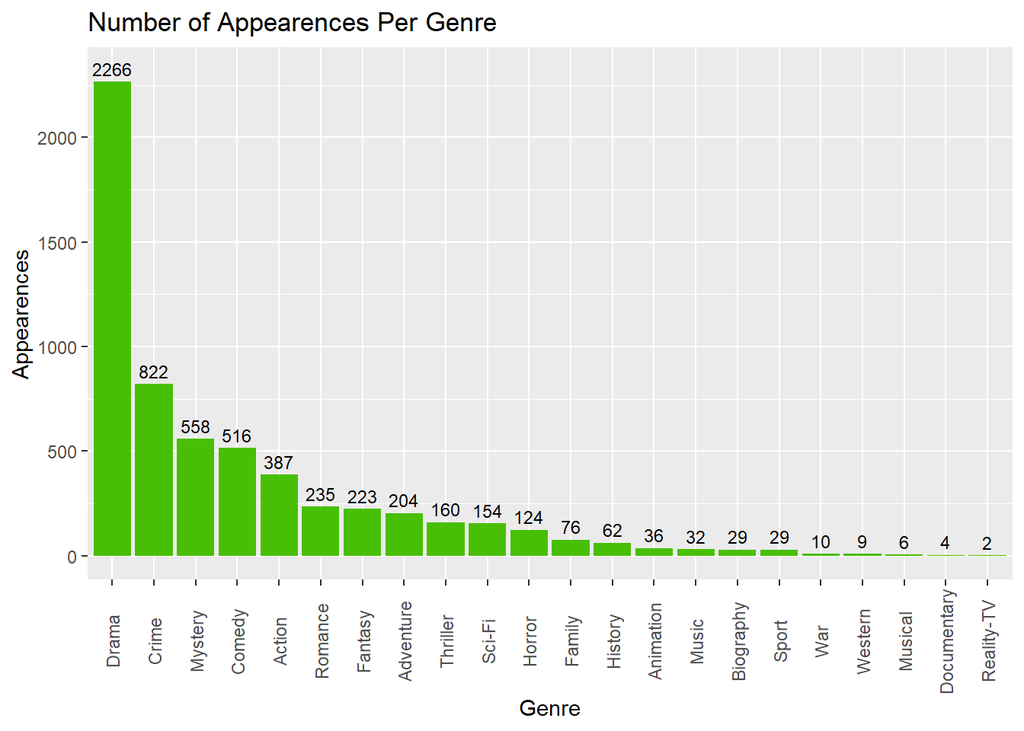

```r
data.frame(genres=all_of(genres.types),
           appearences=unname(tv.data %>%
                                select(all_of(genres.types)) %>%
                                colSums())) %>% slice_max(appearences, n=length(genres.types)) %>%
  {ggplot(., aes(x=factor(genres, levels= genres), y=appearences)) +
      geom_col(fill="#48BF04") + xlab('Genre') + ylab('Appearences') +
      ggtitle('Number of Appearences Per Genre') +
      theme(axis.text.x = element_text(angle = 90, vjust = 0.5)) +
      geom_text(aes(label=sprintf("%.0f", appearences),
                    y=appearences + 50), size=3, vjust=0.3)}
```

From the above graph, we can see that “Drama” appears in every TV show genre description (which makes sense since the data set itself covers TV dramas from 1990 to 2018). Following this we can see that “Crime”, “Mystery”, and “Comedy” are the next most common sub-genres (since every show is also a Drama). An idea we may want to explore is whether we can condense these sub-genres down into more broad categories (i.e. combine genres like Action/Adventure or Thriller/Horror) and see how this effects the above graph.

#### Average Rating Per Genre

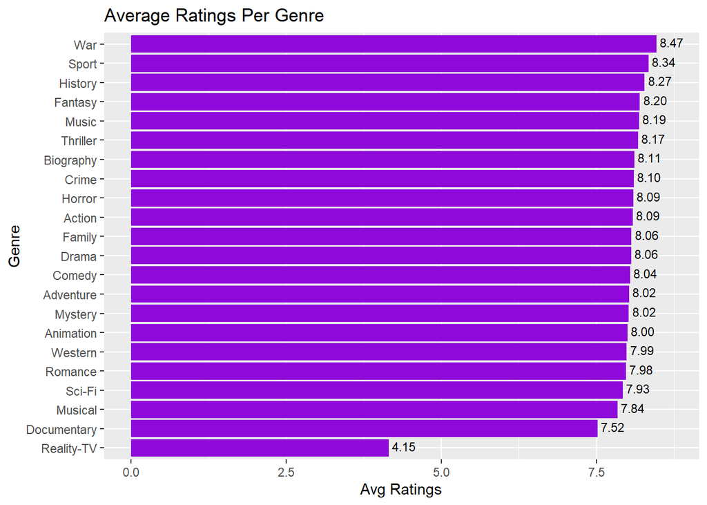

```r
data.frame(genres=all_of(genres.types),
           avg_ratings=(tv.data %>% select(all_of(genres.types)) %>%
                          mutate_each(funs(.*tv.data$av_rating)) %>%
                          colSums()) / (tv.data %>%
                                          select(all_of(genres.types)) %>%
                                          colSums())) %>% slice_max(avg_ratings, n=length(genres.types)) %>%
  {ggplot(., aes(x=fct_rev(factor(genres, levels= genres)), y=avg_ratings)) +
      geom_col(fill="#8F0ADA") + xlab('Genre') + ylab('Avg Ratings') +
      ggtitle('Average Ratings Per Genre') +
      geom_text(aes(label=sprintf("%.2f", avg_ratings),y=avg_ratings + 0.25), size=3, vjust=0.3) +
      coord_flip()}
```

I’m not gonna say I called this one but look at “Reality-TV”… If you’ve ever seen an episode of *Keeping up with the Kardashians* or *Real Housewives of any major city in America* then you’d agree with that number. But besides that, it seems that most fall into the average range of 7.5 to 8.5 (a more reasonable number). It seems that surprisingly, TV shows relating to “War” are the highest rated, followed by “Sports” and “History”. Near the bottom, but not nearly as bad as Reality-TV, we have “Musical” and “Documentaries” coming in last place.